# Styling av figurer i matplotlib

**Læringsmål:**

- Bli kjent med valg av farge/linjestil o.l. for grafer
- Lære å merke kurver i figurer med flere grafer

**Oversikt:**

- Oppgave a) valg av farge
- Oppgave b) valg av linjestil
- Oppgave c) valg av punktmarkør
- Oppgave d) merkelapper

## Om valgfrie parametere og plot()-funksjonen

En ting som er kjekt å kunne før vi går videre er *valgfrie parametre*. Dette blir ofte brukt i store funksjoner som har potensiale til gjøre mye forskjellig. Da ønsker man gjerne å ha mye fleksibilitet, men ønsker kanskje ikke måtte skrive ned hva man ønsker på alle de ulike innstillingene. Da bruker man parameter som har en `default` verdi.

For å lage en slik funksjon skriver man ned hva default verdien er i funksjons *deklarasjon*. Deretter når man skal bruke funksjonen kan man velge hvor mange paramter man ønsker å endre på. Du trenger ikke full forståelse av dette, men må vite at det går an. Se på kodecellen under for et eksempel før du går videre.

```python
def optional_function(arg0 = 5, arg1 = 10, arg2 = 15):
    print(f"{arg0 = } | {arg1 = } | {arg2 = }")

optional_function()
optional_function(1, 2, 3)
optional_function(1, arg2 = 5)
optional_function(arg1 = 7)
```

```
arg0 = 5 | arg1 = 10 | arg2 = 15
arg0 = 1 | arg1 = 2 | arg2 = 3
arg0 = 1 | arg1 = 10 | arg2 = 5
arg0 = 5 | arg1 = 7 | arg2 = 15
```

Mange funksjoner vi bruker i Python har slike optional-parametre, og `plot()`-funksjonen til matplotlib er en slik funksjon. For å gi kurven vi skal plotte et spesielt utseende, kan vil legge til en *formateringsstreng* med en rekke nøkkelsymbol som et tredje argument i `plot()`-funksjonen. For eksempel så vil følgende kommando plotte kurven gitt ved punktene i `x` og `y` som en prikkete linje med blå farge:

```
plt.plot(x, y, ':b') # Tegn kurven som en prikkete blå linje
```

Vi skal nå se på ulike "ekstra-instrukser" vi kan gi denne funksjonen for å pynte på grafen vår.

### Farge

Farge er relativt intuitivt å forholde seg til, ihvertfall når man holder seg til basisfargene gitt i tabellen under. Da kan man angi en farge ved å inkludere én enkelt bokstav i formateringsstrengen.

| Bokstav | Farge |
| --- | --- |
| `'b'` | Blå |
| `'g'` | Grønn |

[output not shown]

Du kan lese mer om fargene som er tilgjengelig [her](https://matplotlib.org/stable/users/explain/colors/colors.html#colors-def).

## a)

Gitt funksjonen $f(x) = \sin(x)$, lag et plot som viser kurven til $f(x)$ i intervallet $0\leq x \leq 10$ der fargen på kurven er **svart**.

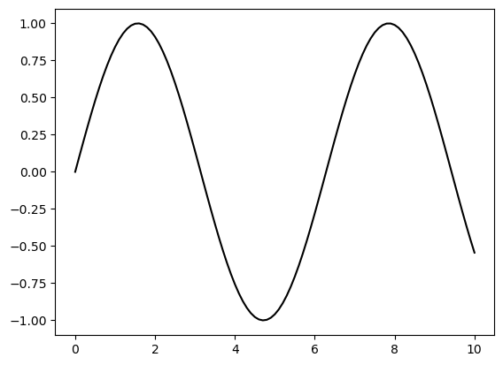

```python
### BEGIN SOLUTION
import numpy as np
import matplotlib.pyplot as plt

def f(x):
    return np.sin(x)

x = np.linspace(0, 10, 101)
plt.plot(x, f(x), 'k')
#plt.plot(x, g(x))
plt.savefig("Figurer/oppg7a_LF.png")
fig = plt.gcf()
### END SOLUTION
```

Har du løst oppgaven riktig skal du se en figur som ser noe slik ut.

All tests passed.

```
2.0
```

### Linjestil

Man kan også endre linjestilen til grafene i matplotlib.

Når man plotter bruker man argumentet `ls` for linjestil, og `color` for farge

Når man bruker `ls` kan man velge mellom 4 alternativer

| Symboler | Linjestil |
| --- | --- |
| `'-'` | Én kontinuerlig linje |
| `':'` | Prikkete linje |
| `'--'` | Strekete linje |
| `'-.'` | Streker og prikker |

## b)

Gitt funksjonen $g(x) = \cos(x)$, lag et plot som viser kurven til $f(x)$ i intervallet $0\leq x \leq 10$ der linjestilen er en prikkete linje.

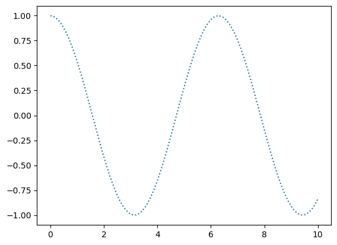

```python
### BEGIN SOLUTION
import numpy as np
import matplotlib.pyplot as plt
def g(x):
    return np.cos(x)
x = np.linspace(0, 10, 101)

plt.plot(x, g(x), ':')
plt.savefig("Figurer/oppg7b_LF.png")
fig = plt.gcf()
### END SOLUTION
```

Har du løst oppgaven riktig skal du se en figur som ser noe slik ut.

All tests passed.

```
2.0
```

### Punktmarkører

Av og til kan det være nyttig å markere punktene som man tenger en kurve gjennom. Da kan man legge til et symbol i formateringsstrengen som oppgir hvordan de ulike punktene skal markeres. Det er veldig mange mulige det går an å velge mellom, men her er et utvalg:

| Symbol | Punktmarkør |
| --- | --- |
| `'o'` | Sirkel $\circ$ |
| `'v'` | Trekant $\triangledown$ |
| `'d'` | Diamant $\diamond$ |
| `'+'` | Kryss $+$ |

## c)

Et sett med $x$- og $y$-korrdinater er gitt i en tabell:

| $$x$$ |  | $$\frac{\pi}{4}$$ | $$\frac{5\pi}{4}$$ | $$\frac{9\pi}{4}$$ |
| --- | --- | --- | --- | --- |
| $$y$$ |  | $$\frac{1}{\sqrt{2}}$$ | $$-\frac{1}{\sqrt{2}}$$ | $$\frac{1}{\sqrt{2}}$$ |

Lag et plot som markerer de tre punktene med diamantsymbol

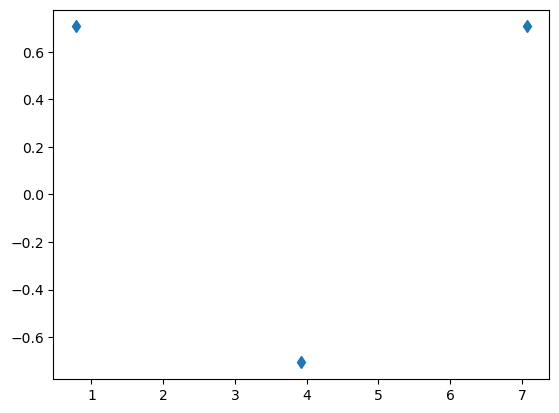

```python
### BEGIN SOLUTION
x = np.array([1, 5, 9])*np.pi/4
y = np.sqrt(0.5)*np.array([1, -1, 1])

plt.plot(x, y, 'd')
plt.savefig("Figurer/oppg7c_LF.png")
fig = plt.gcf()
### END SOLUTION
```

Har du løst oppgaven riktig skal du se en figur som ser noe slik ut.

All tests passed.

```
3.0
```

### Merkelapper

Med flere kurver i samme figur kan det være nyttig med en merkelapp for å differensiere mellom kurvene. Dette gjøres i to steg:

1. Angi teksten i en merkelapp ved å bruke optional parameter `label`
2. La merkelappene vises i plottet ved å kalle funksjonen [`plt.legend()`](https://matplotlib.org/stable/api/_as_gen/matplotlib.pyplot.legend.html)
   - PS: Det er også mulig å spesifisere hvorf merkelappene skal vises ved skrive posisjonen som et optional argument til funksjonen `plt.legend()`. Eksempel: `plt.legend(loc="upper center")`

**Eksempel:**

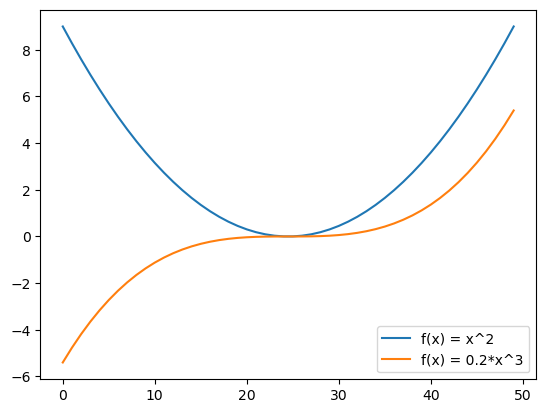

```python
x = np.linspace(-3, 3)
y1 = x**2
y2 = 0.2*x**3
plt.plot(y1, label="f(x) = x^2")
plt.plot(y2, label="f(x) = 0.2*x^3")
plt.legend()
```

## d)

Lag et plot som viser kurven til $f(x)$ fra deloppgave **a)** og $g(x)$ fra deloppgave **b)** i tillegg til punktene i deloppgave **c)**. Kurvene skal merkes med forklarende merkelapper.  
*Til info: punktene fra deloppgave **c** skal markere krysningspunktene til funksjonene $f(x)$ og $g(x)$.*

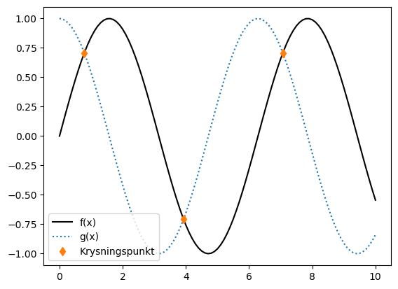

```python
### BEGIN SOLUTION
import numpy as np
import matplotlib.pyplot as plt

def f(x):
    return np.sin(x)

def g(x):
    return np.cos(x)

x = np.linspace(0, 10, 101)
plt.plot(x, f(x), 'k', label="f(x)")
plt.plot(x, g(x), ':', label="g(x)")

x = np.array([1, 5, 9])*np.pi/4
y = np.sqrt(0.5)*np.array([1, -1, 1])
plt.plot(x, y, 'd', label="Krysningspunkt")
plt.legend()
plt.savefig("Figurer/oppg7d_LF.png")
fig = plt.gcf()
### END SOLUTION
```

Har du løst oppgaven riktig skal du se en figur som ser noe slik ut.

All tests passed.

```
3.0
```

[**For mer informasjon om plotting kan denne tutorialen være nyttig!**](https://matplotlib.org/stable/tutorials/pyplot.html)